# Estimating ARIMA Models

Daniel Dala and Asael Alonzo Matamoros

2021-06-17

## Introduction

The core inflation index is used to measure aggregate demand pressures that the action of monetary policy can modify; it is a partial measure derived from inflation calculated through the Consumer Price Index (CPI). This vignette explains how to estimate a ARIMA model to predict the CPI in Honduras for the next years using the functions `check_residuals` and `stan_sarima` in the **bayesforecast** package.

Here we will show how to carry out a few parts of the analysis from Chapter 8.7 of [Hyndman & Khandakar, 2008](http://dx.doi.org/10.18637/jss.v027.i03) that is:

1. Plot the data and identify any unusual observations.
2. Choose a model and check the residuals from your chosen model by plotting the ACF of the residuals.
3. If residuals look like white noise, we calculate the forecasts; otherwise, we choose another model, an adaptation of the Hyndman process and not the whole process as such since, in Bayesian statistics, the AIC and BIC are not commonly used.

Graphing the data:

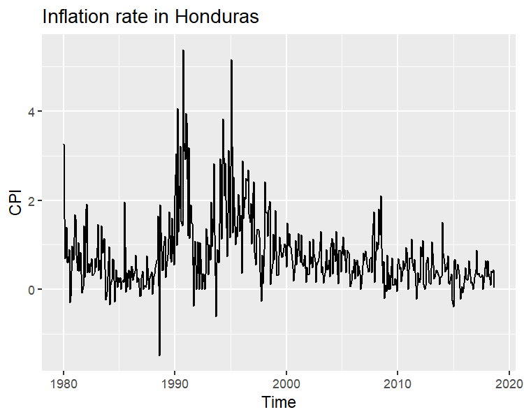

```r
autoplot(object = ipc,main = "Inflation rate in Honduras",ylab="CPI")
```

The previous figure shows that the series does not seem to follow a stationary behavior and has some asymmetry, then the series will be differentiated, and we will graph the correlation graphs.

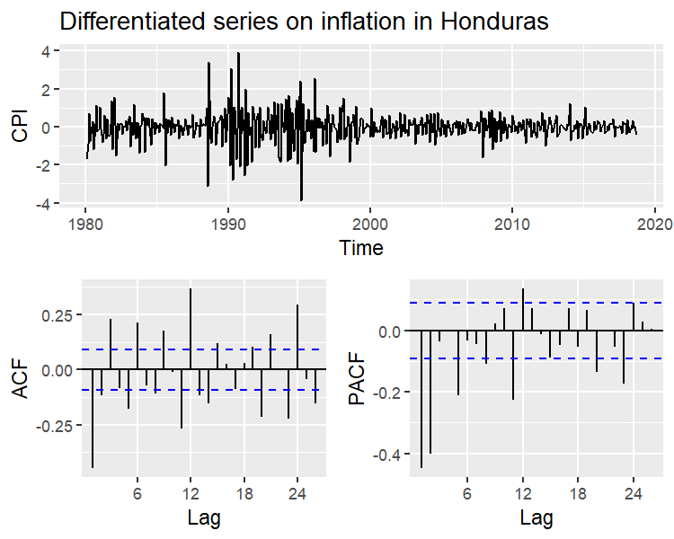

```r
g1 = autoplot(object = diff(ipc),main = "Differentiated series on inflation in Honduras",y = "CPI")
g2 = ggacf(y = diff(ipc))
g3 = ggpacf(y = diff(ipc))


gridExtra::grid.arrange(g1,g2,g3,
                        layout_matrix = matrix(c(1,2,1,3),nrow = 2))
```

**bayesforecast** offers a similar interface to the [rstanarm](https://mc-stan.org/rstanarm/) and forecast packages, the model can be estimated using the following instructions:

```r
sf1 = stan_sarima(ts = ipc,order = c(1,1,1),seasonal = c(1,1,1),
                  prior_sar = beta(2,2),prior_sma = beta(2,2),chains = 1)

summary(sf1)
```

```
#>             mean     se        5%       95%      ess   Rhat
#> mu0       0.0032 0.0002   -0.0078    0.0142 920.8685 1.0001
#> sigma0    0.6452 0.0007    0.6096    0.6822 941.3985 1.0024
#> ar       -0.1919 0.0033   -0.3899   -0.0437 883.2747 1.0042
#> ma       -0.4338 0.0049   -0.6128   -0.0933 945.8398 1.0020
#> sar      -0.2616 0.0032   -0.3877   -0.0646 996.8215 0.9993
#> sma      -0.3511 0.0041   -0.6743   -0.2041 841.9779 1.0017
#> loglik -443.0468 0.0582 -446.5720 -440.6317 784.8410 1.0000
```

To check the adjustment of each parameter, we review the chains and density graphs of each model:

[figure not shown]

```r
mcmc_plot(object = sf1)
```

The chains seem to converge and not observed multimodality in the parameter distributions. Therefore, we consider accepting the estimation of the parameters; we proceed to review the fit.

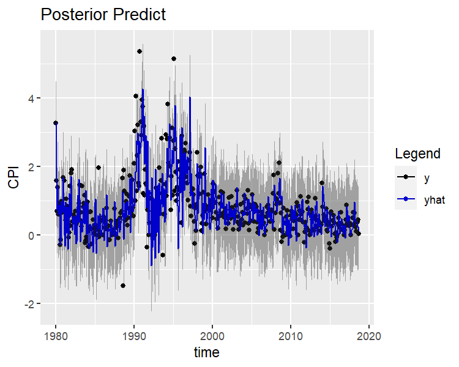

```r
autoplot(sf1)+labs(title = "Posterior Predict", y="CPI")
```

The model seems to fit the series, we proceed to review the model residuals, the `check_residuals` function estimates the posterior mean of the residuals and plots them. This plot is not sufficient to corroborate the assumptions of normality and stationarity but is an initial indicator of the adjustment.

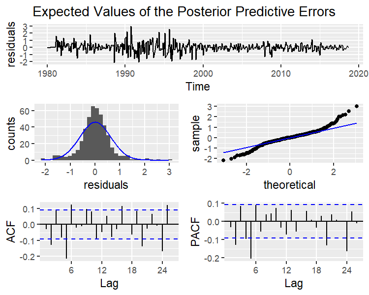

```r
check_residuals(sf1)
```

## Forecast

Finally, we predict the model for the next year:

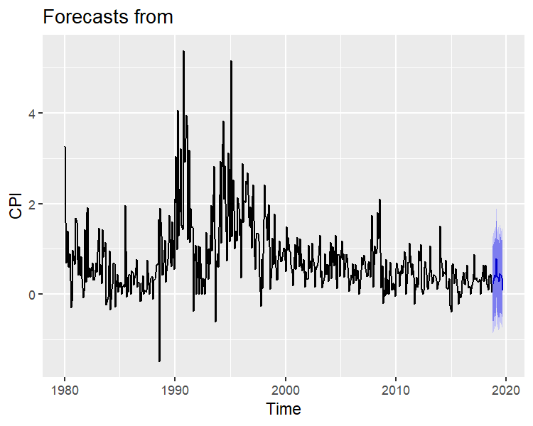

```r
autoplot(object = forecast(sf1,h = 12),ylab="CPI")
```

## References

- Hyndman, R.J., & Athanasopoulos, G. (2018) *Forecasting: principles and practice*, 2nd edition, OTexts: Melbourne, Australia. OTexts.com/fpp2. Accessed on February 17, 2021.
- Carpenter, B., Gelman, A., Hoffman, M., Lee, D., Goodrich, B., Betancourt, M., Brubaker, M., Guo, J., Li, P., & Riddell, A. (2017). *Stan: A Probabilistic Programming Language*. Journal of Statistical Software, 76(1), 1 - 32. doi:http://dx.doi.org/10.18637/jss.v076.i01,
- Hyndman, R., & Khandakar, Y. (2008). *Automatic Time Series Forecasting: The forecast Package for R*. Journal of Statistical Software, 27(3), 1 - 22. doi:http://dx.doi.org/10.18637/jss.v027.i03.